# project-1-checkpoint3

Author

Jasmine Cabrera

# External Data

## Libraries

```r
# libraries
library(rvest)
library(tidyverse)
library(rnaturalearth)
library(sf)
library(gt)
library(httr)
library(tidyjson)
library(jsonlite)
library(glue)

# measles_year dataset
measles_year <- read_csv(here::here("data", "measles_year.csv"))
head(measles_year)
```

```
# A tibble: 6 × 15
  Region Country `Country Code`  Year `Total Pop.` `Annualized Pop. 2025`
  <chr>  <chr>   <chr>          <dbl>        <dbl>                  <dbl>
1 AFRO   Algeria DZA             2013     38414172               38414172
2 AFRO   Algeria DZA             2014     39205031               39205031
3 AFRO   Algeria DZA             2015     40019529               40019529
4 AFRO   Algeria DZA             2016     40850721               40850721
5 AFRO   Algeria DZA             2017     41689299               41689299
6 AFRO   Algeria DZA             2018     42505035               42505035
# ℹ 9 more variables: `Total Suspected Cases` <dbl>, `Total Measles` <dbl>,
#   `Total Lab Measles` <dbl>, `Total Epi Measles` <dbl>,
#   `Total Clinical Measles` <dbl>, `Total Measles per Million` <dbl>,
#   `Total Discarded` <dbl>, `Total Discarded per Million` <dbl>, ASCII <chr>
```

## Motivation:

Measles continues to affect millions of people worldwide each year, despite major scientific advancements and the availability of an effective vaccine. We aim to explore the socioeconomic and geographic factors that may influence measles infection rates. By analyzing these patterns, we hope to better understand disparities across regions and identify populations at higher risk. Countries in Africa are of particular interest, as they are among the most heavily impacted by the measles disease.

**Source:** https://www.who.int/news/item/05-12-2019-more-than-140-000-die-from-measles-as-cases-surge-worldwide

# Webscraping:

Like many diseases, measles transmission is influenced by environmental conditions. Research suggests that the virus is less likely to thrive in extremely cold or hot temperatures, while lower relative humidity can make it easier to spread. It is also important to consider a country’s life expectancy at birth, as it offers insight into overall healthcare quality and the level of development.

**Source:** https://www.tandfonline.com/doi/full/10.4161/hv.27826#d1e168

### get_info_from_page():

pulls information from a website.

```r
get_info_from_page <- function(page, css_selector, node, type) {

  # grab the css and node elements from the page
  if (type == "temp"){
  page |>
    html_element(css_selector) |>
    html_elements(node) |>
    html_text(trim = TRUE)}

  else if(type == "url"){
  page |>
    html_elements(node) |>
    html_attr("href")}

  else {
  page |>
    html_elements(node) |>
    html_text2()}}
```

## Scrape Average Yearly Temperature

**Source:** https://en.wikipedia.org/wiki/List_of_countries_by_average_yearly_temperature

**Data Description:** Wikipedia has data on the average yearly temperature across multiple countries.

### scrape_temp_page():

calls get_info_from_page() and grabs different elements, combining into clean dataframe.

```r
scrape_temp_page <- function(url) {

    # 1 second crawl delay
    Sys.sleep(1)

    # read in page
    page <- read_html(url)

    # country/region
    country_region <- get_info_from_page(page,
                                         css_selector = "table.wikitable",
                                         node = "tbody tr td:nth-child(2)",
                                         type = "temp")

    # continent
    continent <- get_info_from_page(page,
                                    css_selector = "table.wikitable",
                                    node = "tbody tr td:nth-child(3)",
                                    type = "temp")

    # temp
    temp <- get_info_from_page(page,
                               css_selector = "table.wikitable",
                               node = "tbody tr td:nth-child(4)",
                               type = "temp")

    # Put page elements into a data frame / tibble
    tibble(Country = country_region,
           Continent = continent,
           Temperature = temp)}
```

```r
# apply to temp page
url <- "https://en.wikipedia.org/wiki/List_of_countries_by_average_yearly_temperature"
temperature_df <- scrape_temp_page(url)
```

clean temperature dataframe:

```r
# split temperature col into celsius and fahrenheit
temperature_df <- temperature_df |>
  mutate(`Avg. Celsius` = as.numeric(str_extract(Temperature, "\\d+\\.\\d+")),
         `Avg. Fahrenheit` = as.numeric(str_extract(Temperature, "(?<=\\()\\d+\\.\\d+"))) |>
  select(-Temperature)

head(temperature_df)
```

```
# A tibble: 6 × 4
  Country      Continent     `Avg. Celsius` `Avg. Fahrenheit`
  <chr>        <chr>                  <dbl>             <dbl>
1 Burkina Faso Africa                  30.4              86.7
2 Mali         Africa                  29.2              84.6
3 Aruba        South America           29.2              84.5
4 Senegal      Africa                  28.9              84.0
5 Mauritania   Africa                  28.8              83.9
6 Tokelau      Oceania                 28.7              83.7
```

## Scrape Life Expectancy

**Source:** https://data.worldbank.org/country

**Data Description:** The world bank group has large amounts of data relating to a given country’s socioeconomic factors.

### grab_urls():

scrapes the data.worldbank.org page for all of the urls for each country

```r
grab_urls <- function(country_url){
  # read page
  page <- read_html(country_url)

  # links
  country_links <- get_info_from_page(page,
                                      css_selector = "",
                                      node = "section.nav-item ul li a",
                                      type = "url")

  # country
  country <- get_info_from_page(page,
                                css_selector = "",
                                node = "section.nav-item ul li a",
                                type = "text")
  # full url
  tibble(link = paste0("https://data.worldbank.org", country_links),
         country = country)}
```

Keep relevant countries for more efficient webscraping

```r
# grab urls
country_url <- "https://data.worldbank.org/country"
all_country_urls <- grab_urls(country_url)

# countries are not exactly named the same
measles_year |>
  filter(!ASCII %in% all_country_urls$country) |>
  pull(Country) |>
  unique()
```

```
 [1] "Congo"
 [2] "Democratic Republic of the Congo"
 [3] "Gambia"
 [4] "United Republic of Tanzania"
 [5] "Bahamas"
 [6] "Bolivia (Plurinational State of)"
 [7] "Saint Kitts and Nevis"
 [8] "Saint Lucia"
 [9] "Saint Vincent and the Grenadines"
[10] "United States of America"
[11] "Venezuela (Bolivarian Republic of)"
[12] "Egypt"
[13] "Iran (Islamic Republic of)"
[14] "Somalia"
[15] "Yemen"
[16] NA
[17] "Kyrgyzstan"
[18] "Netherlands (Kingdom of the)"
[19] "Republic of Moldova"
[20] "Slovakia"
[21] "United Kingdom of Great Britain and Northern Ireland"
[22] "Democratic People's Republic of Korea"
[23] "Cook Islands"
[24] "Lao People's Democratic Republic"
[25] "Micronesia (Federated States of)"
[26] "Niue"
[27] "Republic of Korea"
```

```r
# clean country col to match
all_country_urls <- all_country_urls |>
  separate_wider_delim(country,
                       delim = ",",
                       names = c("country", "country_extra"),
                       too_few = "align_start") |>
  mutate(country = str_replace_all(country, "(?i)st\\.", "Saint"),
         country = case_when(str_detect(country_extra, "Dem\\.") ~ paste("Democratic", country),
                             TRUE ~ country),
         country = recode_values(country,
                                 "Lao PDR" ~ "Lao",
                                 "Kyrgyz Republic" ~ "Kyrgyzstan",
                                 "Slovak Republic" ~ "Slovakia",
                                 default = country)) |>
         select(-country_extra)


# clean ASCII col to match
measles_year <- measles_year |>
  mutate(ASCII = str_replace_all(ASCII, "\\s*\\(.*?\\)", ""),
         ASCII = str_remove_all(ASCII, "(?i)\\bRepublic of (the )?"),
         ASCII = str_remove_all(ASCII, "(?i)\\bPeople's\\s*"),
         ASCII = recode_values(ASCII,
                          "United Kingdom of Great Britain and Northern Ireland" ~ "Ireland",
                          "United States of America" ~ "United States",
                          "Lao Democratic Republic" ~ "Lao",
                          "United Tanzania" ~ "Tanzania",
                          "Democratic Republic of the Congo" ~ "Democratic Congo",
                          default = ASCII),
         ASCII = str_trim(ASCII))

# check changes were made
measles_year |>
  filter(!ASCII %in% all_country_urls$country) |>
  pull(Country) |>
  unique()
```

```
[1] NA             "Cook Islands" "Niue"
```

The website does not like large calls, so we have to resort to batches.

```r
# grab africa countries
measles_africa <- measles_year |>
  filter(Region == "AFRO")

# keep only countries in measles_year
africa_country_urls <- all_country_urls |>
  filter(country %in% measles_africa$ASCII)

# grab amro countries
measles_amro <- measles_year |>
  filter(Region == "AMRO")

amro_country_urls <- all_country_urls |>
  filter(country %in% measles_amro$ASCII)

# grab emro countries
measles_emro <- measles_year |>
  filter(Region == "EMRO")

emro_country_urls <- all_country_urls |>
  filter(country %in% measles_emro$ASCII)

# grab euro countries
measles_euro <- measles_year |>
  filter(Region == "EURO")

euro_country_urls <- all_country_urls |>
  filter(country %in% measles_euro$ASCII)

# grab searo countries
measles_searo <- measles_year |>
  filter(Region == "SEARO")

searo_country_urls <- all_country_urls |>
  filter(country %in% measles_searo$ASCII)

# grab wpro countries
measles_wpro <- measles_year |>
  filter(Region == "WPRO")

wpro_country_urls <- all_country_urls |>
  filter(country %in% measles_wpro$ASCII)
```

### scrape_country_page():

scrapes a country’s data.worldbank.org page for its life expectancy

```r
scrape_country_page <- function(url) {

    # 1 second crawl delay
    Sys.sleep(runif(1, min = 4, max = 6))

    # read in page
    page <- read_html(url)

    # le_node
    le_node <- page |>
    html_elements(".indicator-item") |>
    keep(~str_detect(html_text(.x), "Life expectancy at birth"))

    # life_exp
    life_exp <- le_node |>
    html_element(".indicator-item__data-info span") |>
    html_text2() |>
    as.numeric()

    # year
    year <- le_node |>
    html_element(".indicator-item__data-info-year") |>
    html_text2() |>
    str_extract("\\d{4}") |>
    as.numeric()

    # Put page elements into a data frame / tibble
    tibble(life_exp = life_exp,
           year = year)}
```

```r
# webscrape in batches
africa_life_exp <- map(.x = africa_country_urls$link,
                       .f = scrape_country_page) |>
                   bind_rows()

amro_life_exp <- map(.x = amro_country_urls$link,
                     .f = scrape_country_page) |>
                 bind_rows()

emro_life_exp <- map(.x = emro_country_urls$link,
                     .f = scrape_country_page) |>
                 bind_rows()

euro_life_exp <- map(.x = euro_country_urls$link,
                     .f = scrape_country_page) |>
                 bind_rows()

searo_life_exp <- map(.x = searo_country_urls$link,
                     .f = scrape_country_page) |>
                 bind_rows()

wpro_life_exp <- map(.x = wpro_country_urls$link,
                     .f = scrape_country_page) |>
                 bind_rows()


# combine countries and life expectancies
africa_life_exp <- cbind(africa_country_urls, africa_life_exp)
amro_life_exp <- cbind(amro_country_urls, amro_life_exp)
emro_life_exp <- cbind(emro_country_urls, emro_life_exp)
euro_life_exp <- cbind(euro_country_urls, euro_life_exp)
searo_life_exp <- cbind(searo_country_urls, searo_life_exp)
wpro_life_exp <- cbind(wpro_country_urls, wpro_life_exp)
all_life_exp <- bind_rows(africa_life_exp, amro_life_exp, emro_life_exp,
                          euro_life_exp, searo_life_exp, wpro_life_exp)

# save to csv
all_life_exp |>
  write_csv("measles_life_expectancy_data.csv")
```

```r
# load in csv
life_exp_data <- read.csv(here::here("data", "measles_life_expectancy_data.csv"))
life_exp_data <- life_exp_data |>
  select(-c(link, year)) |>
  rename(Country = country,
         `Life Expectancy 2024` = life_exp)

head(life_exp_data)
```

```
       Country Life Expectancy 2024
1      Algeria                   76
2       Angola                   65
3        Benin                   61
4     Botswana                   69
5 Burkina Faso                   61
6      Burundi                   64
```

## Join and Clean DF

Join temperature and life expectancy to measles_year dataframe

```r
# join temperature
measles_year <- measles_year |>
  left_join(temperature_df, by = "Country") |>
  left_join(life_exp_data, by = c("ASCII" = "Country"))

head(measles_year)
```

```
# A tibble: 6 × 19
  Region Country `Country Code`  Year `Total Pop.` `Annualized Pop. 2025`
  <chr>  <chr>   <chr>          <dbl>        <dbl>                  <dbl>
1 AFRO   Algeria DZA             2013     38414172               38414172
2 AFRO   Algeria DZA             2014     39205031               39205031
3 AFRO   Algeria DZA             2015     40019529               40019529
4 AFRO   Algeria DZA             2016     40850721               40850721
5 AFRO   Algeria DZA             2017     41689299               41689299
6 AFRO   Algeria DZA             2018     42505035               42505035
# ℹ 13 more variables: `Total Suspected Cases` <dbl>, `Total Measles` <dbl>,
#   `Total Lab Measles` <dbl>, `Total Epi Measles` <dbl>,
#   `Total Clinical Measles` <dbl>, `Total Measles per Million` <dbl>,
#   `Total Discarded` <dbl>, `Total Discarded per Million` <dbl>, ASCII <chr>,
#   Continent <chr>, `Avg. Celsius` <dbl>, `Avg. Fahrenheit` <dbl>,
#   `Life Expectancy 2024` <int>
```

## Summaries and Visualizations

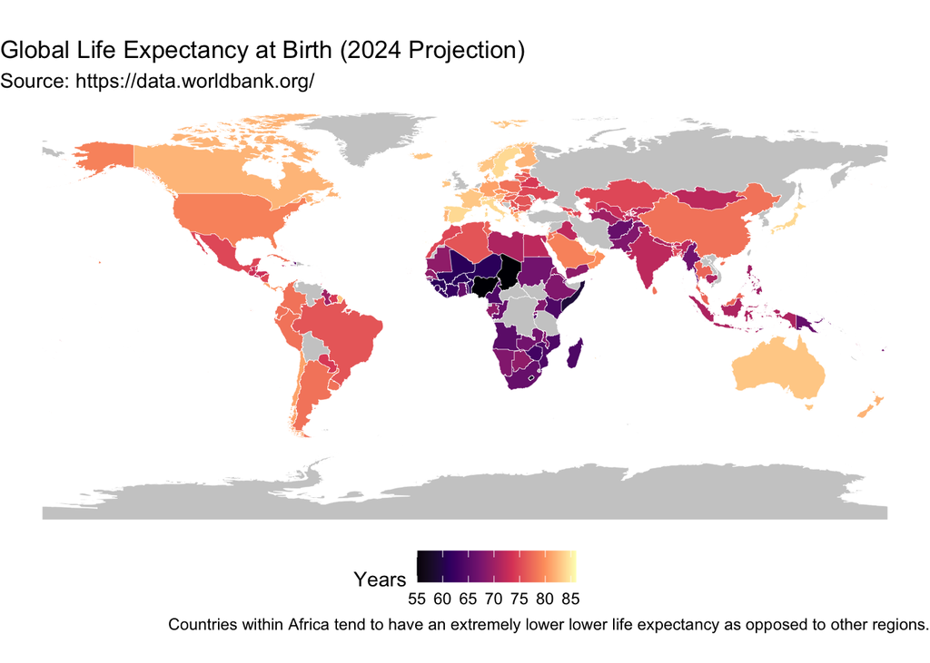

```r
# load world map data
world <- ne_countries(scale = "medium", returnclass = "sf")

world_life_exp <- world |>
  left_join(measles_year |>
            distinct(Country, `Life Expectancy 2024`),
            by = c("name" = "Country"))

ggplot(data = world_life_exp) +
  geom_sf(aes(fill = `Life Expectancy 2024`),
          color = "white", size = 0.1) +
  scale_fill_viridis_c(option = "magma",
                       na.value = "grey80", name = "Years") +
  theme_void() +
  labs(title = "Global Life Expectancy at Birth (2024 Projection)",
       caption = "Countries within Africa tend to have an extremely lower lower life expectancy as opposed to other regions.",
       subtitle = "Source: https://data.worldbank.org/") +
  theme(legend.position = "bottom")
```

```r
plot_data <- measles_year |>
  group_by(Country, ASCII, Region, `Life Expectancy 2024`) |>
  summarize(total_rate_avg = mean(`Total Measles per Million`, na.rm = TRUE),
            .groups = "drop")

region_medians <- plot_data |>
  group_by(Region) |>
  summarize(median_life_exp = median(`Life Expectancy 2024`, na.rm = TRUE),
            median_rate = median(total_rate_avg, na.rm = TRUE))

region_medians |>
  gt() |>
  tab_header(title = md(paste0("Median Measles Rate Across Each Region"))) |>
  cols_label("Region" = md("**Region**"),
               "median_life_exp" = md("**Median Life Expectancy (years)**"),
               "median_rate" = md("**Median Measles Rate**")) |>
  tab_source_note(md("Despite having the lowest median life expectancy, countries in Africa do not have the highest median Measles Rate."))
```

Median Measles Rate Across Each Region

| **Region** | **Median Life Expectancy (years)** | **Median Measles Rate** |
| --- | --- | --- |
| AFRO | 64 | 25.37143 |
| AMRO | 75 | 0.01000 |
| EMRO | 75 | 26.05786 |
| EURO | 80 | 13.00000 |
| SEARO | 73 | 13.02538 |
| WPRO | 72 | 10.54143 |

Despite having the lowest median life expectancy, countries in Africa do not have the highest median Measles Rate.

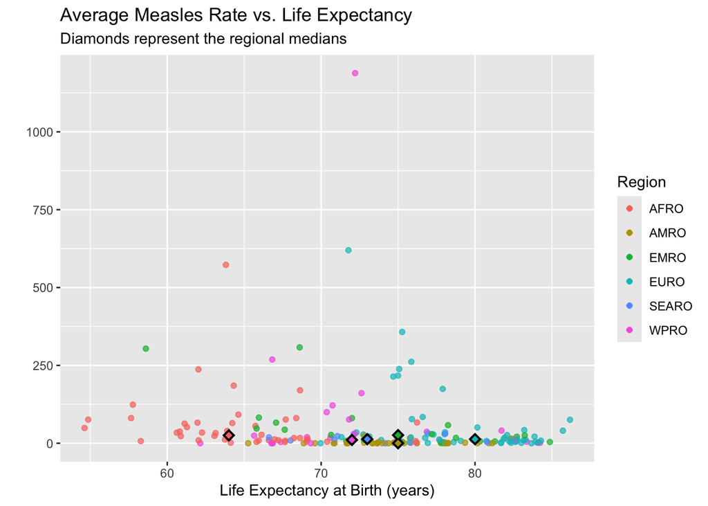

```r
plot_data |>
ggplot(aes(x = `Life Expectancy 2024`, y = total_rate_avg, color = Region)) +
  geom_jitter(alpha = 0.7) +
  geom_point(data = region_medians,
             aes(x = median_life_exp, y = median_rate),
             shape = 18,
             size = 4,
             color = "black") +
  geom_point(data = region_medians,
             aes(x = median_life_exp, y = median_rate),
             shape = 18,
             size = 2) +
  labs(title = "Average Measles Rate vs. Life Expectancy",
       subtitle = "Diamonds represent the regional medians",
       x = "Life Expectancy at Birth (years)",
       y = "")
```

# API

**Source:** https://restcountries.com/

```r
world_df <- GET("https://restcountries.com/v4/all?fields=cca3,geolocation,area,borders,hdi,gini,government,religion") |>
  (\(x) rawToChar(x$content))() |>
  fromJSON() |>
  unnest_wider(c(gini, geolocation, government, religion), "_") |>
  relocate(cca3) |>
  rename("ISO3" = cca3) |>
  arrange(ISO3)

world_df |>
  head(5) |>
  gt() |> tab_header(title = md("REST API Data")) |>
    cols_label(ISO3 = md("**ISO3**"),
               gini_year = md("**GINI Year**"),
               gini_value = md("**GINI Value**"),
               geolocation_latitude = md("**Latitude**"),
               geolocation_longitude = md("**Longitude**"),
               religion_name = md("**Religions**"),
               religion_population = md("**Religion Populations**"),
               religion_percentage = md("**Religion Percentages**"),
               government_type = md("**Government Type**"),
               government_leaders = md("**Government Leaders**"),
               hdi = md("**Human Development Index**"),
               borders = md("**Border Nations**"),
               area = md("**Land Area**")) |>
  fmt_number(decimals = 3, use_seps = TRUE) |>
  tab_caption(md("Table 1. Variables left in lists have varying lengths"))
```

Table 1. Variables left in lists have varying lengths

REST API Data

| **ISO3** | **GINI Year** | **GINI Value** | **Latitude** | **Longitude** | **Religions** | **Religion Populations** | **Religion Percentages** | **Government Type** | **Government Leaders** | **Human Development Index** | **Border Nations** | **Land Area** |
| --- | --- | --- | --- | --- | --- | --- | --- | --- | --- | --- | --- | --- |
| ABW |  |  | 12.500 | −69.967 |  |  |  | Devolution | list(title = c("Monarchy of the Netherlands", "Governor of Aruba"), name = c("Willem-Alexander of the Netherlands", "Alfonso Boekhoudt")) | 0.000 |  | 180.000 |
| AFG |  |  | 33.000 | 65.000 | islam, other | 49950000, 50000 | 99.9, 0.1 | Unitary state | list(title = c("Supreme Leader of Afghanistan", "Prime Minister of Afghanistan"), name = c("Hibatullah Akhundzada", "Hasan Akhund")) | 0.496 | IRN, PAK, TKM, UZB, TJK, CHN | 652,230.000 |
| AGO | 2018 | 51.3 | −12.500 | 18.500 | christianity, no religion, other | 29069176, 4226239, 3454491 | 79.1, 11.5, 9.4 | Unitary presidential republic | list(title = c("President of Angola", "Vice President of Angola"), name = c("João Lourenço", "Esperança da Costa")) | 0.616 | COG, COD, ZMB, NAM | 1,246,700.000 |
| AIA |  |  | 18.250 | −63.167 |  |  |  | constitutional monarchy | list(title = c("Monarchy of the United Kingdom", "Governor of Anguilla"), name = c("Chales III", "Julia Crouch (diplomat)")) | 0.000 |  | 91.000 |
| ALA |  |  | 60.117 | 19.900 |  |  |  | Devolution | list(title = c("State Department of Åland", "Lantråd"), name = c("Marine Holm-Johansson", "Katrin Sjögren")) | 0.937 |  | 1,580.000 |

## Join and Clean API Data

```r
measles_year_clean <- measles_year |>
  left_join(world_df, by = c("Country Code" = "ISO3")) |>
  mutate(Density = `Total Pop.`/area) |>
  select(-c(ASCII, Continent, "Annualized Pop. 2025"))
```